# Project Group 36

**User Knowledge**

```r
library(readxl)
library(tidyverse)
library(repr)
library(caret)
```

```r
user_data <- read_excel("project_data.xlsx") %>% data.frame()
head(user_data)
```

A data.frame: 6 × 6

| STG <dbl> | SCG <dbl> | STR <dbl> | LPR <dbl> | PEG <dbl> | UNS <chr> |
| --- | --- | --- | --- | --- | --- |
| 0.00 | 0.00 | 0.00 | 0.00 | 0.00 | very_low |
| 0.08 | 0.08 | 0.10 | 0.24 | 0.90 | High |
| 0.06 | 0.06 | 0.05 | 0.25 | 0.33 | Low |
| 0.10 | 0.10 | 0.15 | 0.65 | 0.30 | Middle |
| 0.08 | 0.08 | 0.08 | 0.98 | 0.24 | Low |
| 0.09 | 0.15 | 0.40 | 0.10 | 0.66 | Middle |

**Introduction**

This dataset is about the students' knowledge about the subject of Electrical DC machines. The project will answer the question that given a random user vector with five corresponding data (STG, SCG, LPR, PEG), we can classify which study level the user belongs to. The dataset has 6 columns, 5 variables and one classifier, (target value) which are as follows:

- STG (The degree of study time for goal object materails)(variable)
- SCG (The degree of repetition number of user for goal object materails) (variable)
- STR (The degree of study time of user for related objects with goal object) (variable)
- LPR (The exam performance of user for related objects with goal object) (variable)
- PEG (The exam performance of user for goal objects) (variable)
- UNS (The knowledge level of user) (target value)

```r
sum(is.na(user_data))
```

0

```r
set_row <- mutate(user_data, UNS = as.factor(UNS)) %>%
             unlist() %>%
             createDataPartition(p = 0.75, list = FALSE)
head(user_data)
```

A data.frame: 6 × 6

| STG <dbl> | SCG <dbl> | STR <dbl> | LPR <dbl> | PEG <dbl> | UNS <chr> |
| --- | --- | --- | --- | --- | --- |
| 0.00 | 0.00 | 0.00 | 0.00 | 0.00 | very_low |
| 0.08 | 0.08 | 0.10 | 0.24 | 0.90 | High |
| 0.06 | 0.06 | 0.05 | 0.25 | 0.33 | Low |
| 0.10 | 0.10 | 0.15 | 0.65 | 0.30 | Middle |
| 0.08 | 0.08 | 0.08 | 0.98 | 0.24 | Low |
| 0.09 | 0.15 | 0.40 | 0.10 | 0.66 | Middle |

```r
training_set <- user_data %>% slice(set_row)
test_set <- user_data %>% slice(-set_row)
head(training_set)
head(test_set)
```

A data.frame: 6 × 6

| STG <dbl> | SCG <dbl> | STR <dbl> | LPR <dbl> | PEG <dbl> | UNS <chr> |
| --- | --- | --- | --- | --- | --- |
| 0.00 | 0.00 | 0.00 | 0.00 | 0.00 | very_low |
| 0.08 | 0.08 | 0.10 | 0.24 | 0.90 | High |
| 0.06 | 0.06 | 0.05 | 0.25 | 0.33 | Low |
| 0.10 | 0.10 | 0.15 | 0.65 | 0.30 | Middle |
| 0.08 | 0.08 | 0.08 | 0.98 | 0.24 | Low |
| 0.09 | 0.15 | 0.40 | 0.10 | 0.66 | Middle |

A data.frame: 6 × 6

| STG <dbl> | SCG <dbl> | STR <dbl> | LPR <dbl> | PEG <dbl> | UNS <chr> |
| --- | --- | --- | --- | --- | --- |
| 0.10 | 0.10 | 0.43 | 0.29 | 0.56 | Middle |
| 0.15 | 0.02 | 0.34 | 0.40 | 0.01 | very_low |
| 0.20 | 0.14 | 0.35 | 0.72 | 0.25 | Low |
| 0.20 | 0.20 | 0.70 | 0.30 | 0.60 | Middle |
| 0.12 | 0.12 | 0.75 | 0.35 | 0.80 | High |
| 0.10 | 0.25 | 0.10 | 0.08 | 0.33 | Low |

```r
# n is the number of observations
summary_table <- user_data %>%
 group_by(UNS) %>%
 summarize(n=n())

mean_for_each_class <- user_data %>%
      group_by(UNS) %>%
      summarize(STG_mean = mean(STG), SCG_mean = mean(SCG),STR_mean = mean(STR),LPR_mean = mean(LPR),PEG_mean = mean(PEG))

table <- merge(summary_table, mean_for_each_class)
table
```

A data.frame: 4 × 7

| UNS <chr> | n <int> | STG_mean <dbl> | SCG_mean <dbl> | STR_mean <dbl> | LPR_mean <dbl> | PEG_mean <dbl> |
| --- | --- | --- | --- | --- | --- | --- |
| High | 63 | 0.4216508 | 0.4231905 | 0.5016667 | 0.5012698 | 0.77253968 |
| Low | 83 | 0.3211446 | 0.3370000 | 0.4307229 | 0.4973494 | 0.23762651 |
| Middle | 88 | 0.3999773 | 0.3679205 | 0.5068182 | 0.3428409 | 0.54238636 |
| very_low | 24 | 0.3057917 | 0.1981250 | 0.3662500 | 0.3587500 | 0.09083333 |

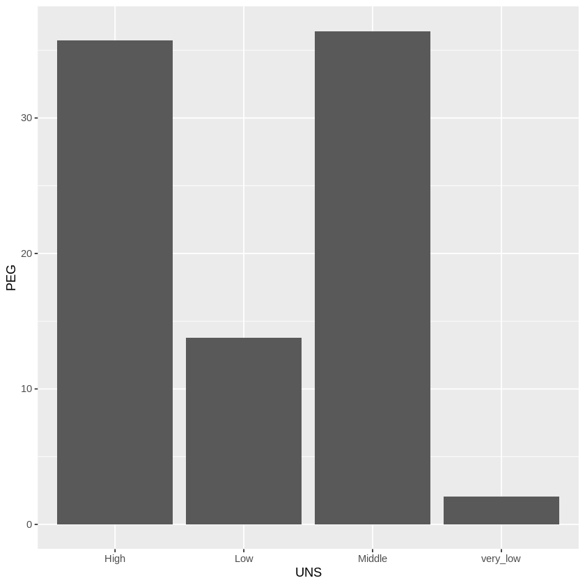

```r
data_plot_peg <- training_set %>%
  ggplot(aes(x = UNS, y = PEG)) +
    geom_bar(stat = "identity") +
    labs(x = "UNS", y = "PEG")
data_plot_peg
```

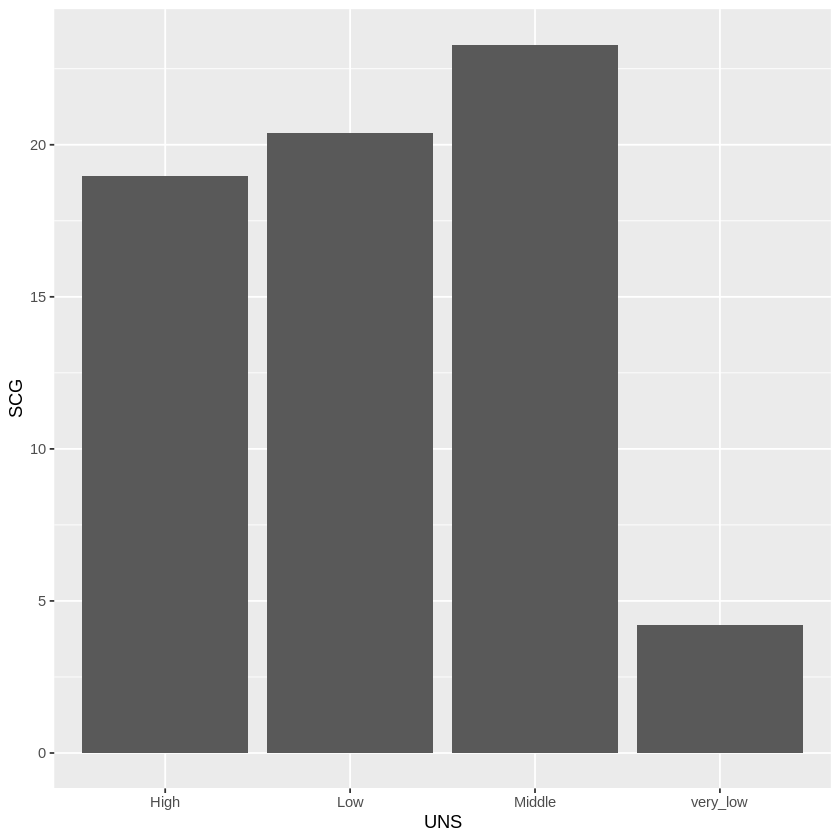

```r
data_plot_peg <- training_set %>%
  ggplot(aes(x = UNS, y = SCG)) +
    geom_bar(stat = "identity") +
    labs(x = "UNS", y = "SCG")
data_plot_peg
```

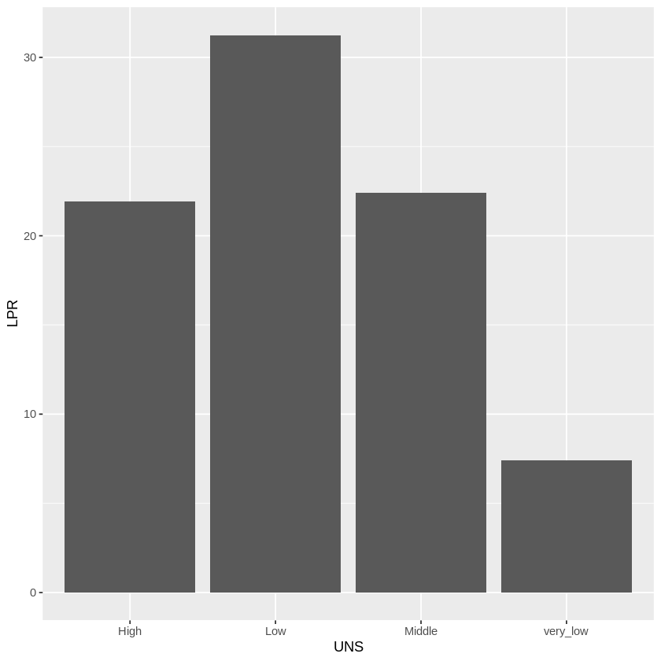

```r
data_plot_peg <- training_set %>%
  ggplot(aes(x = UNS, y = LPR)) +
    geom_bar(stat = "identity") +
    labs(x = "UNS", y = "LPR")
data_plot_peg
```

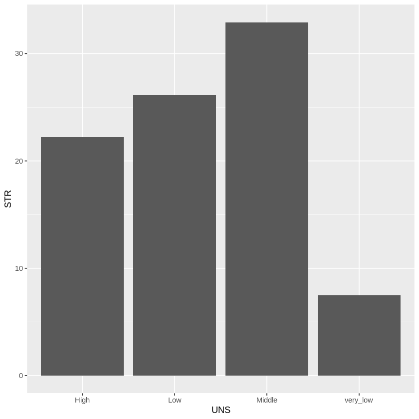

```r
data_plot_peg <- training_set %>%
  ggplot(aes(x = UNS, y = STR)) +
    geom_bar(stat = "identity") +
    labs(x = "UNS", y = "STR")
data_plot_peg
```

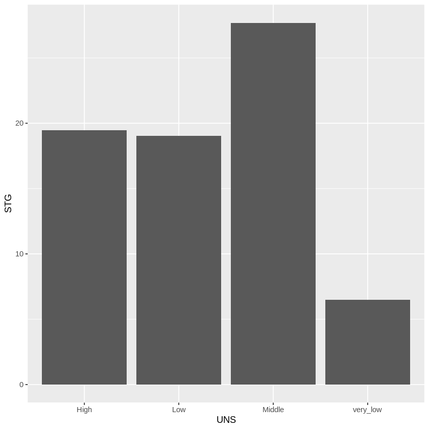

```r
data_plot_peg <- training_set %>%
  ggplot(aes(x = UNS, y = STG)) +
    geom_bar(stat = "identity") +
    labs(x = "UNS", y = "STG")
data_plot_peg
```

**Methods**

Cleaning and Wrangling : This dataset does not require much cleaning since there is no missing values and moreover, each variable in this dataset has a column associated with it which corresponds to a single value in one cell.

Visualization: A scatter plot will be used since we will be utilizing it to demonstrate overfitting and underfitting later in the analysis. When comparing various variables against one another.

**Expected Outcomes and Significance**

Expectations : Through this assignment, we expect to find which specific variables and patterns of studying will help us develop the habits of good students. The project will help understand which specific factors are important to develop into a well-performing student.

Impact : The findings of the assignment will help us decode which factors and habits help separate high performing students from the rest of the pack. A clear vision can then be implemented in order to reach academic goals.

Future Questions : The results will also serve as the basis for further research into what exactly is required of students with regard to improving their academic prowess. The findings will help to get a fair, data-driven analogy of the topic and provide a good base for looking into how productivity can be improved in academics.

**Word Count** : 384 words (excluding code)